# R Notebook

Iram Contractor

The ABC Marketing Consultancy claims that its new advertising strategy will net an *increase* in sales for certain categories of companies. To test ABC’s claim, a consortium of businesses hire a statistical consultant. The statistician gathers the past sales of LaTeX: n=10 consortium members before and after they had used ABC. She then calculates the difference in sales by subtracting the *before* sales from the *after* sales to obtain these data (in 10 thousand): y = c(5, 5, 4, 4, 5, 5, 4, 5, 4, 4)

```r
y = c(5, 5, 4, 4, 5, 5, 4, 5, 4, 4)
```

1.1 Determines the sample mean

```r
mean (y)
```

```
## [1] 4.5
```

1.2 Determine the sample standard deviation

```r
sd(y)
```

```
## [1] 0.5270463
```

1.3 She denotes the unknown mean of the net difference of “after-before” sales by μ and the unknown standard deviation by σ. She also assumes that the net difference has a *normal* distribution denoted by Y N(μ, σ).

Suppose the mean is μ=0 and the standard deviation is σ=1, what is the 0.975 quantile of the N(0, 1) distribution?

```r
m=0
s=1
qnorm(0.975, 0, 1)
```

```
## [1] 1.959964
```

1.4 Suppose the mean is μ=0. But since no one really knows the standard deviation, the statistician will substitute the estimate s, the sample standard deviation (use R command sd() to compute it).

What is the 0.975 quantile of the LaTeX: N(0, s) distribution?

```r
m=0
qnorm(0.975, 0, sd(y))
```

```
## [1] 1.032992
```

Where n is the size of the sample. Now σy¯is called the standard error of the mean.

Suppose σ= 1, what is the standard error of the mean for a sample of size n = 10.

```r
n=10
(standard_error = 1/sqrt(n))
```

```
## [1] 0.3162278
```

1.6 What is the 0.975 quantile of the N(0,σy¯) distribution using the value of σy¯ found in the above exercise?

```r
qnorm(0.975, 0, standard_error)
```

```
## [1] 0.619795
```

1.7 Now the statistician knows that she must estimate σy¯ from the data. If she substitutes s for σ in the formula for the standard error of the mean, what is the value she finds?

This value is denoted by sy¯.

```r
(sample_standard_error = sd(y)/sqrt(n))
```

```
## [1] 0.1666667
```

1.8 What is the 0.975 quantile of the N(0,sy¯) distribution using the value of sy¯ found in the above exercise?

```r
qnorm(0.975,0, sd(y)/sqrt(n))
```

```
## [1] 0.3266607
```

2. The ToyotaPrices dataset resides in the Dropbox Folder (/#lectures/# data) with an MS Excel file type as well as a CSV file type.

Download and Import the data into R Studio.

```r
library(readxl)
ToyotaPrices = ("C:/Users/contr/Downloads/ToyotaPrices.xlsx")
```

2.1 Compute the summary() of the dataframe.

Determine if any values could be declared missing, and then convert the values to missing NA. (Beware, this may take many lines of code!)

Rerun the summary() function.

```r
summary(ToyotaPrices)
```

```
##    Length     Class      Mode
##         1 character character
```

Determine if any values could be declared missing, and then convert the values to missing NA.

```r
library(readxl)
ToyotaPrices <- read_excel("C:/Users/contr/Downloads/ToyotaPrices.xlsx")
View(ToyotaPrices)
sort(ToyotaPrices$KM)[1:50]
```

```
##  [1]     1     1     1     1     1     1     1     1    15   225   450  1500
## [13]  2000  3000  4000  5000  5000  5278  5309  5459  6000  6000  6155  6250
## [25]  6500  7000  7000  7187  7650  8537  8574  9750  9788 10000 10000 10000
## [37] 10000 10000 10000 10077 10210 10841 11000 11000 11090 11500 11754 11999
## [49] 12000 12500
```

#Missing values # Convert all the variables miscoded as $1$ for missing value

```r
ToyotaPrices$KM[ToyotaPrices$KM == 1] = NA
summary(ToyotaPrices$KM)
```

```
##    Min. 1st Qu.  Median    Mean 3rd Qu.    Max.    NA's
##      15   43188   63635   68917   87295  243000       8
```

```r
summary(ToyotaPrices)
```

```
##        Id             Price         Age_08_04       Mfg_Month
##  Min.   :   1.0   Min.   : 4350   Min.   : 1.00   Min.   : 1.000
##  1st Qu.: 361.8   1st Qu.: 8450   1st Qu.:44.00   1st Qu.: 3.000
##  Median : 721.5   Median : 9900   Median :61.00   Median : 5.000
##  Mean   : 721.6   Mean   :10731   Mean   :55.95   Mean   : 5.549
##  3rd Qu.:1081.2   3rd Qu.:11950   3rd Qu.:70.00   3rd Qu.: 8.000
##  Max.   :1442.0   Max.   :32500   Max.   :80.00   Max.   :12.000
##
##     Mfg_Year          KM               HP          Automatic
##  Min.   :1998   Min.   :    15   Min.   : 69.0   Min.   :0.00000
##  1st Qu.:1998   1st Qu.: 43188   1st Qu.: 90.0   1st Qu.:0.00000
##  Median :1999   Median : 63635   Median :110.0   Median :0.00000
##  Mean   :2000   Mean   : 68917   Mean   :101.5   Mean   :0.05571
##  3rd Qu.:2001   3rd Qu.: 87295   3rd Qu.:110.0   3rd Qu.:0.00000
##  Max.   :2004   Max.   :243000   Max.   :192.0   Max.   :1.00000
##                 NA's   :8
##        cc            Doors         Cylinders     Gears       Quarterly_Tax
##  Min.   : 1300   Min.   :2.000   Min.   :4   Min.   :3.000   Min.   : 19.00
##  1st Qu.: 1400   1st Qu.:3.000   1st Qu.:4   1st Qu.:5.000   1st Qu.: 69.00
##  Median : 1600   Median :4.000   Median :4   Median :5.000   Median : 85.00
##  Mean   : 1577   Mean   :4.033   Mean   :4   Mean   :5.026   Mean   : 87.12
##  3rd Qu.: 1600   3rd Qu.:5.000   3rd Qu.:4   3rd Qu.:5.000   3rd Qu.: 85.00
##  Max.   :16000   Max.   :5.000   Max.   :4   Max.   :6.000   Max.   :283.00
##
##      Weight     Mfr_Guarantee    BOVAG_Guarantee  Guarantee_Period
##  Min.   :1000   Min.   :0.0000   Min.   :0.0000   Min.   : 3.000
##  1st Qu.:1040   1st Qu.:0.0000   1st Qu.:1.0000   1st Qu.: 3.000
##  Median :1070   Median :0.0000   Median :1.0000   Median : 3.000
##  Mean   :1072   Mean   :0.4095   Mean   :0.8955   Mean   : 3.815
##  3rd Qu.:1085   3rd Qu.:1.0000   3rd Qu.:1.0000   3rd Qu.: 3.000
##  Max.   :1615   Max.   :1.0000   Max.   :1.0000   Max.   :36.000
##
##       ABS            Airbag_1         Airbag_2          Airco
##  Min.   :0.0000   Min.   :0.0000   Min.   :0.0000   Min.   :0.0000
##  1st Qu.:1.0000   1st Qu.:1.0000   1st Qu.:0.0000   1st Qu.:0.0000
##  Median :1.0000   Median :1.0000   Median :1.0000   Median :1.0000
##  Mean   :0.8134   Mean   :0.9708   Mean   :0.7228   Mean   :0.5084
##  3rd Qu.:1.0000   3rd Qu.:1.0000   3rd Qu.:1.0000   3rd Qu.:1.0000
##  Max.   :1.0000   Max.   :1.0000   Max.   :1.0000   Max.   :1.0000
##
```

[output cut: 17 more lines]

```
##  Min.   :0.0000   Min.   :0.0000   Min.   :0.0000   Min.   :0.0000
##  1st Qu.:0.0000   1st Qu.:1.0000   1st Qu.:0.0000   1st Qu.:0.0000
##  Median :0.0000   Median :1.0000   Median :0.0000   Median :0.0000
##  Mean   :0.3001   Mean   :0.7702   Mean   :0.2047   Mean   :0.1455
##  3rd Qu.:1.0000   3rd Qu.:1.0000   3rd Qu.:0.0000   3rd Qu.:0.0000
##  Max.   :1.0000   Max.   :1.0000   Max.   :1.0000   Max.   :1.0000
##
##     Tow_Bar
##  Min.   :0.0000
##  1st Qu.:0.0000
##  Median :0.0000
##  Mean   :0.2779
##  3rd Qu.:1.0000
##  Max.   :1.0000
##
```

2.2 Convert a categorical variable to factor

Which variables are categorical?

Convert Tow_Bar to factor and change the levels to meaningful lables.

After doing the conversions run the summary() function on Tow_Bar.

```r
ToyotaPrices$Tow_Bar = factor(ToyotaPrices$Tow_Bar)
levels(ToyotaPrices$Tow_Bar) = c("absent", "present")
summary(ToyotaPrices$Tow_Bar)
```

```
##  absent present
##    1037     399
```

2.3 Explore the distribution of Price.

Prepare the necessary plots, such as the histogram/density overlay plot, the normal QQ-plot.

Is the variable normal?

Is the variable skewed?

Are there any groupings, if so speculate why this is happening?

You can use ggplot2 .

```r
library(ggplot2)
plot1 <- ggplot(ToyotaPrices) +
  aes( x = Price, y = ..density..) +
  geom_histogram( fill ="purple",
                  colour ="black",
                  size =0.2) +
  geom_density()
```

```r
plot2 <- ggplot(ToyotaPrices) +
  aes( sample = Price) +
  geom_qq() +
  geom_qq_line(color="green")
```

2.4 Put all your plots into one screen.

You can use gridExtra.

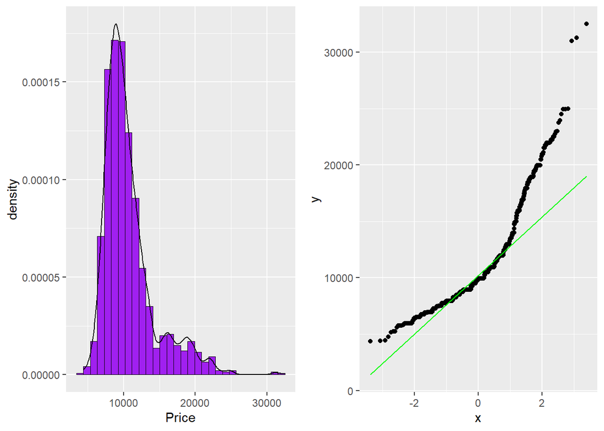

```r
library(gridExtra)

grid.arrange(plot1, plot2, ncol=2)
```